CMU · 36-315 Statistical Graphics & Visualization · Course Project

# Distinguishing Human and LLM‑Generated Text Using Linguistic Features

**Anwei Yan****Ting Chen****Kevin Bao**

01 — Summary

## Do machines write differently?

As AI-generated content becomes increasingly prevalent, understanding how machine-generated language differs from human writing matters for detection, evaluation, and broader NLP applications. This project asks whether linguistic features can distinguish human-written text from text generated by large language models — and whether that difference is uniform or feature-specific.

Using the Human–AI Parallel English Corpus (HAP‑E), we analyze 66 quantitative linguistic features spanning tense, pronouns, syntax, and discourse. Exploratory analysis, logistic regression, and supervised modeling show that linguistic features can meaningfully predict a text's source — in particular, features tied to pronoun usage, tense, sentence structure, and subordination were the most informative signals. Broadly, LLM-generated text leans on more generalized and structurally complex language, while human writing is more context-dependent and referentially grounded — though these differences are highly feature-specific rather than categorical.

Unsupervised analysis told a different story. PCA and hierarchical clustering revealed no strong natural separation between the two sources: observations substantially overlapped in reduced feature space, meaning the selected features are far better suited to supervised classification than to unsupervised discovery. We also found measurable differences between instruction-tuned and non-instruction-tuned LLMs, suggesting training objective itself leaves a linguistic signature.

Overall, linguistic features offer an interpretable but limited lens: authorship leaves a real signal in the grammar, but it's a signal built from many small, feature-specific effects rather than one dominant pattern.

02 — Data

## The HAP‑E corpus

We use the Human–AI Parallel English Corpus (HAP‑E), built on the Biber (1988) feature set, available from the [CMU S&DS Data Repository](https://cmustatistics.github.io/data-repository/language/hap-e.html). The corpus is built from 12,000 original texts collected from a variety of real-world sources. For each, two ~500-word chunks were extracted: the first became a prompt asking an LLM to continue in the same style; the second — the original human continuation — anchors a direct, parallel comparison. Each row is one 500-word chunk.

- Human The original chunk, written by the source's human author.
- LLM The generated continuation, produced by several models including GPT‑4o and Llama, both pretrained and instruction-tuned.

The response variables are 66 linguistic features from multidimensional register analysis (Biber, 1988) — rates per 1,000 words across tense & aspect, pronouns & reference, syntactic structure, lexical complexity, and discourse markers.

03 — Research Questions

## Three angles on one question

- Can linguistic features distinguish between human- and LLM-generated texts?
- Can *unsupervised* clusters of linguistic features distinguish human- and LLM-generated texts?
- Are there differences between instruction-tuned and non-instruction-tuned LLMs in linguistic features?

04 — Results, RQ1

✎ Anwei Yan

## Which features separate human from LLM text — and how well?

### Group A · Tense and aspect markers

Tense and aspect capture how a text represents time and action — a natural place to look for narrative or descriptive style differences.

Table 1 · Mean values of Group A features by source

| Source | Past tense | Perfect aspect | Present tense |
| --- | --- | --- | --- |
| Human | 39.706 | 7.316 | 57.733 |
| LLM | 39.034 | 6.469 | 57.420 |

Mean values alone are strikingly similar between sources — perfect aspect runs slightly higher for humans, but the gap is small. Averages alone provide limited evidence; the distributions and a model need a closer look.

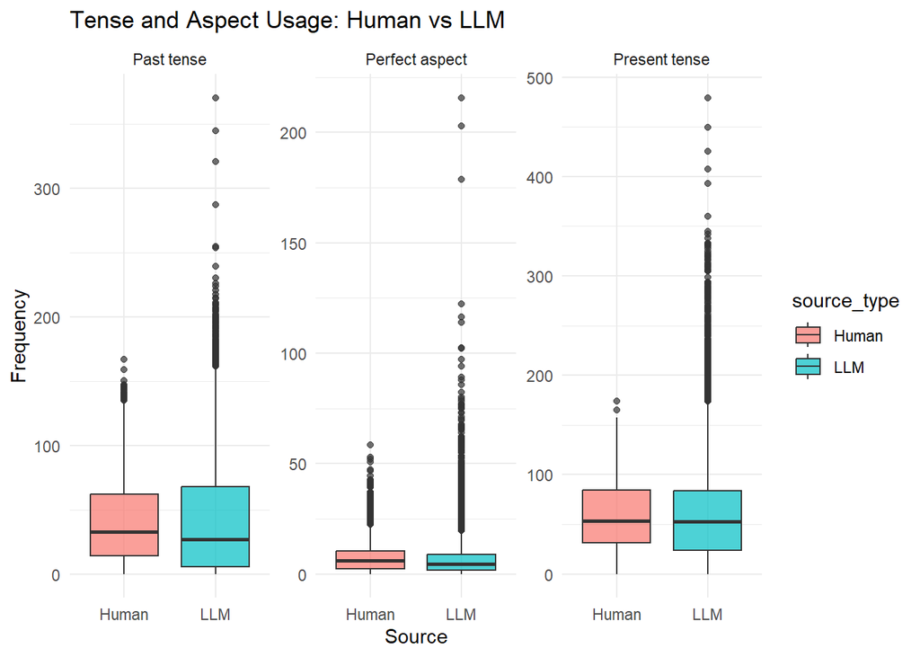

**Fig. 1** — Medians largely overlap, but LLM text shows noticeably more spread and more extreme values — the difference lives more in variability than central tendency.

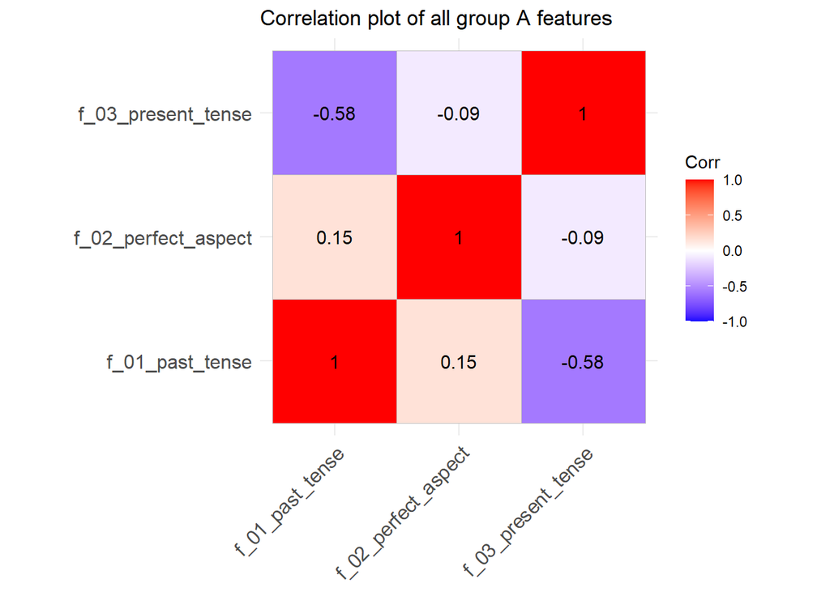

**Fig. 2** — Past and present tense are moderately negatively correlated (texts favor one temporal register over the other); perfect aspect is only weakly related to either, capturing a distinct dimension.

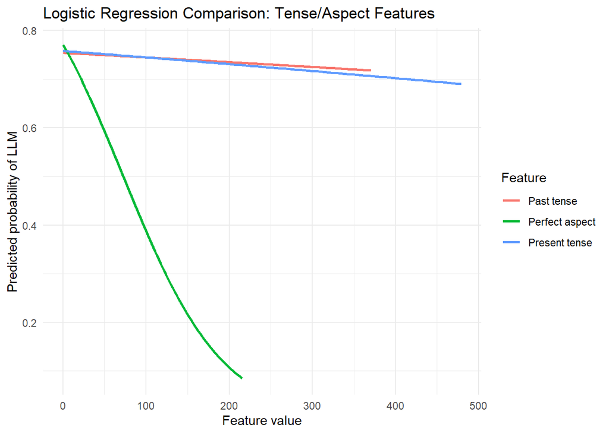

**Fig. 3** — Logistic regression on these three features alone: perfect aspect has real pull toward the human class as usage rises, past/present tense are weaker. Predicted probabilities mostly stay above 0.5 — tense and aspect are a weak signal on their own.

### Group B · Pronouns

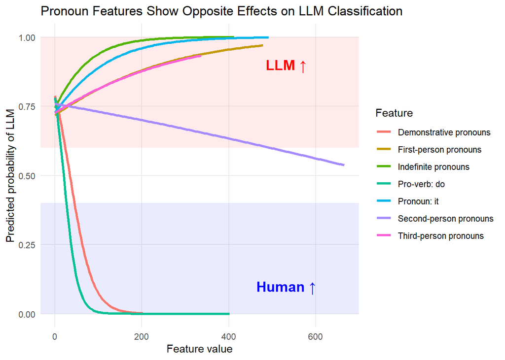

**Fig. 4** — A much sharper split than Group A. First-/third-person, it, and indefinite pronouns push toward LLM; demonstratives and the pro-verb do push sharply toward human. Pronoun choice carries real information about source.

LLMs lean on generalized, descriptive reference; demonstratives and do-support read as distinctly human habits of speech.

### Group C · Subordination features

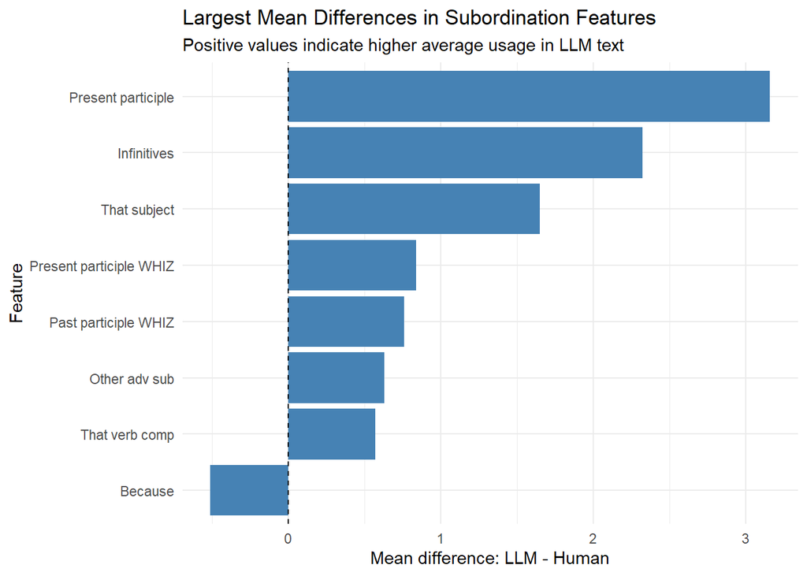

**Fig. 5** — Largest mean gaps, LLM minus human. Most run positive — more present participles, infinitives, that-subjects in LLM text — while because skews human, hinting at more direct, causal, conversational phrasing.

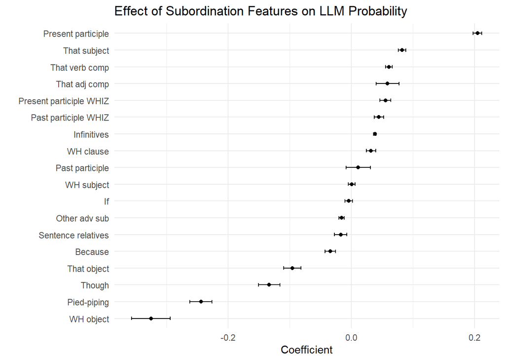

**Fig. 6** — Regression coefficients agree: present participles and that-subjects push toward LLM; WH-object constructions, pied-piping, and though push toward human.

**Takeaway:** linguistic features do distinguish sources, but unevenly — pronoun usage and subordination structure carry real signal; tense and aspect barely do. LLM text trends structurally complex and generalized; human text trends context-grounded and referentially direct.

05 — Results, RQ2

✎ Ting Chen

## Do sources form natural clusters?

To use all 66 features at once, and to look beyond human-vs-LLM at differences between model families, we ran Principal Component Analysis on the full feature set. PCA is sensitive to class size and LLM samples outnumber human ones, so we downsampled every source to the smallest group's count first.

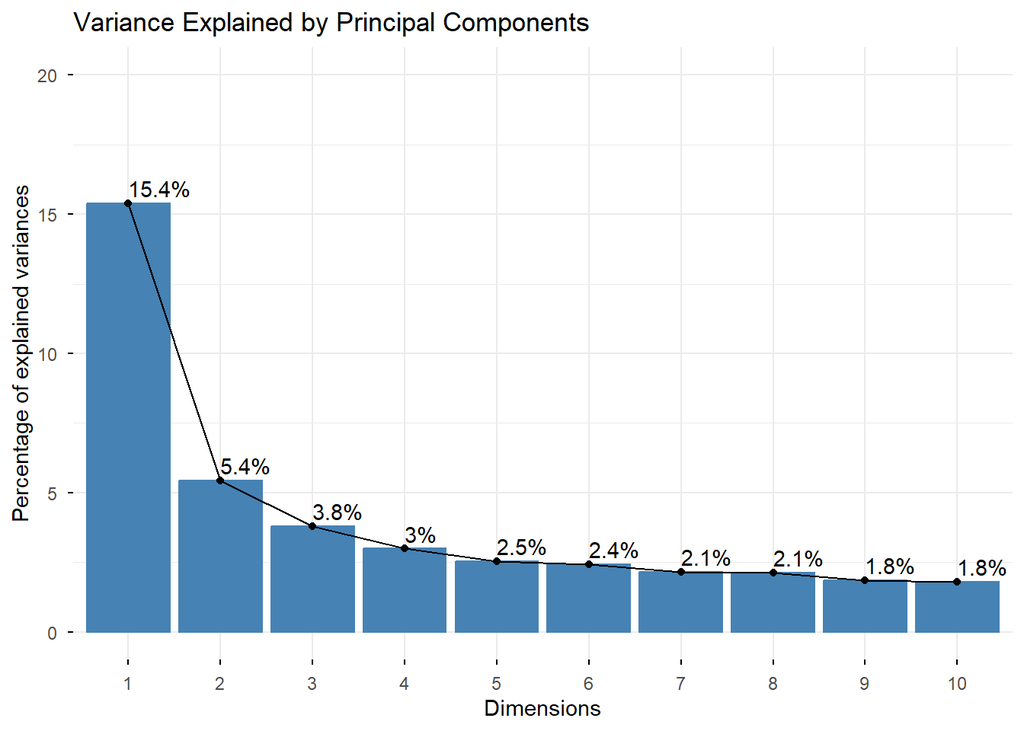

**Fig. 7** — No single dominant component: PC1 explains only 15.4% of variance. Linguistic variation here is spread across many dimensions, not concentrated in one.

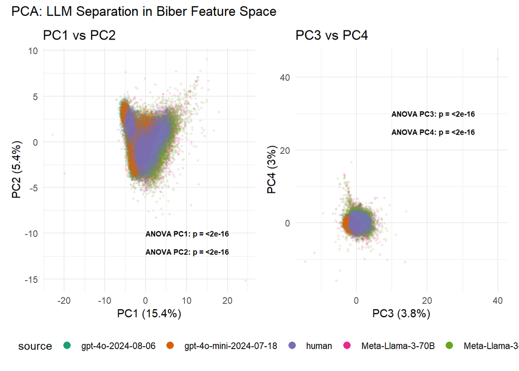

**Fig. 8** — PC1–PC4, colored by source. ANOVA confirms sources differ significantly on every component shown — but the point clouds still overlap heavily. Human texts cluster somewhat tighter; some LLM families (notably Llama) spread wider.

We also built a dendrogram from a 10-per-source sample, using Euclidean distance in standardized feature space.

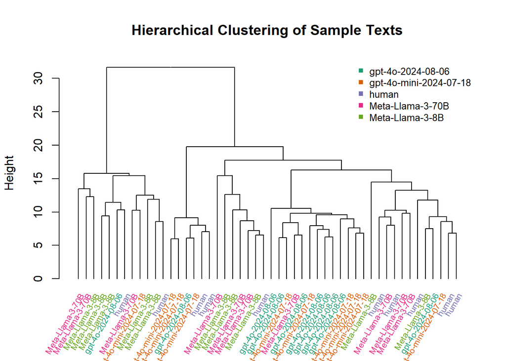

**Fig. 9** — Human and LLM texts interleave across branches rather than splitting into two clean clusters — only a few small same-source groupings appear.

**Takeaway:** sources are statistically distinguishable on every PCA axis, yet share enough overall stylistic structure that unsupervised methods can't cleanly separate them. These 66 features are built for supervised classification and interpretation — not for unsupervised discovery.

06 — Results, RQ3

✎ Kevin Bao

## Does instruction-tuning change how a model writes?

Instruction tuning is meant to make a model follow human intent more closely — does that process also leave a mark on its grammar? We compare four Llama‑3 checkpoints (8B/70B, base vs. Instruct); GPT‑4o variants are excluded here since both are instruction-tuned and can't provide a within-family contrast.

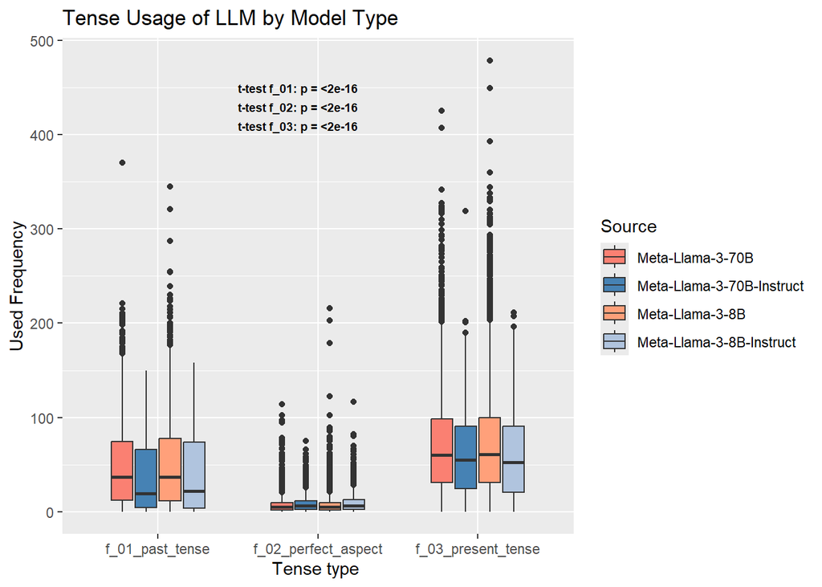

**Fig. 10** — Non-instruction-tuned checkpoints trend toward more past- and present-tense usage; instruction-tuned checkpoints trend slightly higher on perfect aspect. A t-test across the three tense features returns p ≈ 1.23×10⁻¹³⁶ — significant, though largely a function of the corpus's very large sample size rather than a dramatic visual gap.

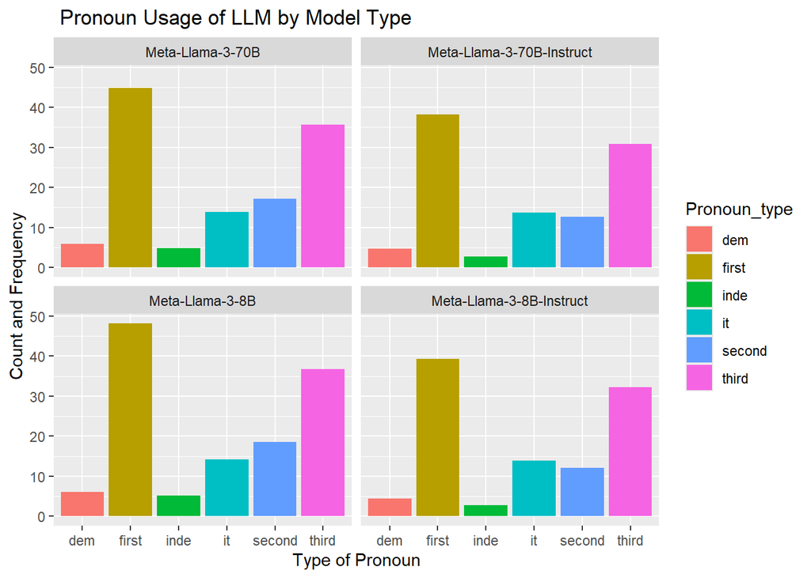

**Fig. 11** — First- and third-person pronouns dominate across every model. Instruction-tuned checkpoints use slightly less of nearly every pronoun type except it — a modest shift toward a more controlled, neutral register, not a change in the overall pattern.

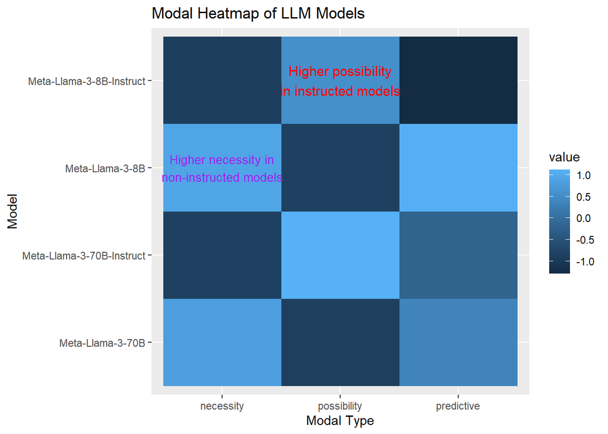

**Takeaway:** instruction tuning doesn't overhaul a model's grammar, but it does nudge it — toward hedged, flexible, lower-certainty phrasing, and modestly reduced pronoun use. Neither style reads as objectively "better," just differently calibrated.

07 — Future Work

## Open threads

Instruction-tuning differences, while real, are modest next to the base human/LLM gap — consistent with the PCA finding that no single axis cleanly separates any of these groups. And because Biber features summarize text numerically, some information is necessarily lost: metadata like genre or the human prompt-writer, and finer-grained signals like specific keyword or co-occurrence patterns, could sharpen the picture if layered on top of the linguistic feature set used here.

08 — References

## References

1. Biber, D. (1988). *Variation Across Speech and Writing.* Cambridge University Press.